# assignment 1

Ruicong(Timothy) Du

2025-02-26

# Question a

In this analysis, I will fit a **LASSO regression model** to predict house sale prices using various characteristics.

## Load Required Libraries

```r
library(glmnet)
library(caret)
library(tidymodels)
library(ggplot2)
library(dplyr)
library(readr)
library(pls)
```

## Load and Preprocess Data

```r
# Load data
train_data = read_csv("./housing_training.csv", na = c("NA","","."))
test_data = read_csv("./housing_test.csv",na = c("NA","","."))

# Extract response variable
y_train = train_data$Sale_Price
X_train = train_data %>% select(-Sale_Price)
X_test = test_data

# Encode categorical variables
X_train = model.matrix(~., data = X_train)[,-1]
X_test = model.matrix(~., data = X_test)[,-1]

# Ensure X_test has the same structure as X_train
X_test <- X_test[, colnames(X_train), drop = FALSE]

# Standardize predictors
X_train = scale(X_train)
X_test = scale(X_test)
```

## Fit LASSO Model with Cross-Validation

```r
set.seed(2)
lasso_cv = cv.glmnet(X_train, y_train, alpha = 1, nfolds = 10)

# Extract optimal lambda values
lambda_min = lasso_cv$lambda.min
lambda_1se = lasso_cv$lambda.1se

# Fit model with lambda_1se
lasso_1se = glmnet(X_train, y_train, alpha = 1, lambda = lambda_1se)
num_predictors_1se = sum(coef(lasso_1se) != 0)
```

## Model Results

```r
# Extract coefficients for lambda_min
lasso_coef <- predict(lasso_cv, s = lambda_min, type = "coefficients")

# Display nonzero coefficients
lasso_coef_df <- as.data.frame(as.matrix(lasso_coef))
lasso_coef_df <- lasso_coef_df[lasso_coef_df != 0, , drop = FALSE]  # Keep only nonzero coefficients

# Print the coefficients
print(lasso_coef_df)
```

```
##                                     s1
## (Intercept)                177568.5021
## Gr_Liv_Area                 31885.0887
## First_Flr_SF                  288.9982
## Total_Bsmt_SF               14622.8394
## Low_Qual_Fin_SF             -1831.9070
## Wood_Deck_SF                 1577.9644
## Open_Porch_SF                 999.9787
## Bsmt_Unf_SF                 -8669.7416
## Mas_Vnr_Area                 1801.1737
## Garage_Cars                  2991.9030
## Garage_Area                  1616.8318
## Year_Built                   9516.8215
## TotRms_AbvGrd               -5680.6581
## Full_Bath                   -2179.8997
## Overall_QualAverage         -2246.8923
## Overall_QualBelow_Average   -3262.8925
## Overall_QualExcellent       12534.7683
## Overall_QualFair            -1339.7250
## Overall_QualGood             4963.4000
## Overall_QualVery_Excellent  12657.8246
## Overall_QualVery_Good       11593.7602
## Kitchen_QualFair            -3273.9016
## Kitchen_QualGood            -8702.3117
## Kitchen_QualTypical        -12904.9203
## Fireplaces                   7073.4755
## Fireplace_QuFair            -1287.4581
## Fireplace_QuNo_Fireplace      989.5142
## Fireplace_QuPoor             -746.0453
## Fireplace_QuTypical         -2877.8248
## Exter_QualFair              -3565.9666
## Exter_QualGood              -7850.4939
## Exter_QualTypical          -10182.4949
## Lot_Frontage                 3274.2018
## Lot_Area                     5018.1570
## Longitude                    -892.7147
## Latitude                     1033.0143
## Misc_Val                      511.1469
## Year_Sold                    -765.6260
```

```r
cat("Optimal lambda (lambda_min):", lambda_min, "\n")
```

```
## Optimal lambda (lambda_min): 38.51706
```

```r
cat("Lambda using 1SE rule (lambda_1se):", lambda_1se, "\n")
```

```
## Lambda using 1SE rule (lambda_1se): 756.1055
```

```r
cat("Number of predictors in model (1SE rule):", num_predictors_1se, "\n")
```

```
## Number of predictors in model (1SE rule): 31
```

## Test Set Prediction and MSE

```r
y_pred <- predict(lasso_cv, newx = as.matrix(X_test), s = lambda_min)
test_mse <- mean((y_pred - test_data$Sale_Price)^2)

cat("Test Mean Squared Error:", test_mse, "\n")
```

```
## Test Mean Squared Error: 480000218
```

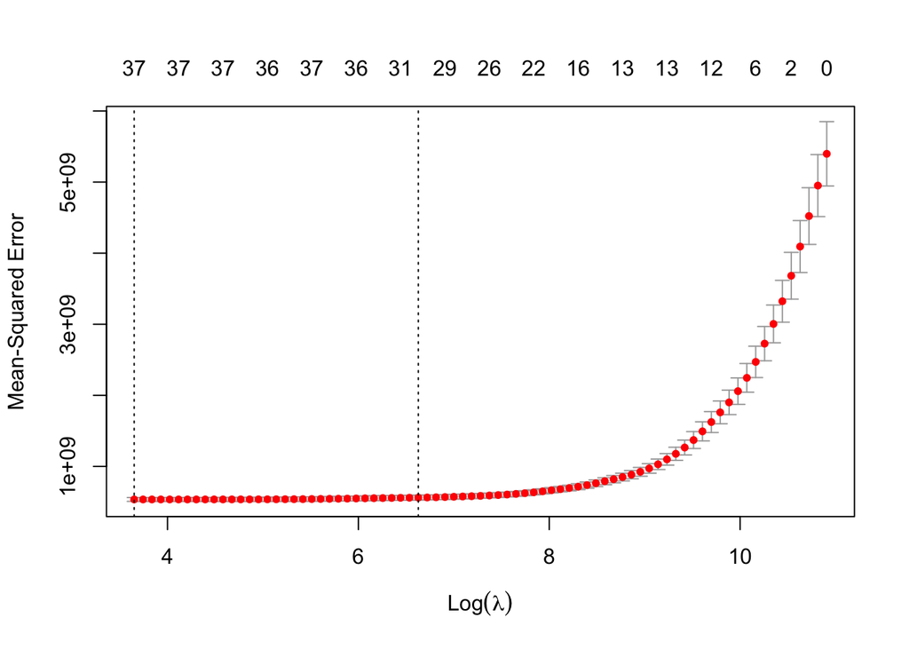

```r
plot(lasso_cv)
```

## Reporting

1. Report the Selected Tuning Parameter The optimal lambda (lambda_min):38.51706 The lambda using the 1SE rule (lambda_1se):756.1055
2. Number of Predictors in the Model (1SE Rule) The number of predictors retained when using the 1SE rule is 31 predictors

3.Test Error (Mean Squared Error):480000218

# Question b

## Fit Elastic Net Model with Cross-Validation

```r
set.seed(2)
elastic_net_cv <- cv.glmnet(X_train, y_train, alpha = 0.5, nfolds = 10)

# Extract optimal lambda values
lambda_min_en <- elastic_net_cv$lambda.min
lambda_1se_en <- elastic_net_cv$lambda.1se

# Fit model with lambda_1se
elastic_net_1se <- glmnet(X_train, y_train, alpha = 0.5, lambda = lambda_1se_en)
num_predictors_1se_en <- sum(coef(elastic_net_1se) != 0)
```

```r
# Extract coefficients for lambda_min
elastic_net_coef <- predict(elastic_net_cv, s = lambda_min_en, type = "coefficients")

# Display nonzero coefficients
elastic_net_coef_df <- as.data.frame(as.matrix(elastic_net_coef))
elastic_net_coef_df <- elastic_net_coef_df[elastic_net_coef_df != 0, , drop = FALSE]

# Print the coefficients
print(elastic_net_coef_df)
```

```
##                                     s1
## (Intercept)                177568.5021
## Gr_Liv_Area                 31705.8657
## First_Flr_SF                  333.4526
## Total_Bsmt_SF               14605.1511
## Low_Qual_Fin_SF             -1825.0836
## Wood_Deck_SF                 1579.5575
## Open_Porch_SF                1002.3347
## Bsmt_Unf_SF                 -8665.5345
## Mas_Vnr_Area                 1829.0273
## Garage_Cars                  2971.8350
## Garage_Area                  1643.8573
## Year_Built                   9488.3827
## TotRms_AbvGrd               -5577.6662
## Full_Bath                   -2116.5984
## Overall_QualAverage         -2248.7308
## Overall_QualBelow_Average   -3255.5699
## Overall_QualExcellent       12618.6128
## Overall_QualFair            -1343.7450
## Overall_QualGood             4952.0261
## Overall_QualVery_Excellent  12749.5767
## Overall_QualVery_Good       11586.6129
## Kitchen_QualFair            -3223.2341
## Kitchen_QualGood            -8527.3823
## Kitchen_QualTypical        -12736.3872
## Fireplaces                   7002.7366
## Fireplace_QuFair            -1289.6459
## Fireplace_QuNo_Fireplace      887.3756
## Fireplace_QuPoor             -746.5256
## Fireplace_QuTypical         -2879.7863
## Exter_QualFair              -3478.6887
## Exter_QualGood              -7464.9772
## Exter_QualTypical           -9798.6533
## Lot_Frontage                 3259.9284
## Lot_Area                     5017.5760
## Longitude                    -889.7464
## Latitude                     1025.9059
## Misc_Val                      503.6790
## Year_Sold                    -748.8452
```

```r
# Report results
cat("Optimal lambda (lambda_min) for Elastic Net:", lambda_min_en, "\n")
```

```
## Optimal lambda (lambda_min) for Elastic Net: 92.78787
```

```r
cat("Lambda using 1SE rule (lambda_1se) for Elastic Net:", lambda_1se_en, "\n")
```

```
## Lambda using 1SE rule (lambda_1se) for Elastic Net: 1377.87
```

```r
cat("Number of predictors in model (1SE rule) for Elastic Net:", num_predictors_1se_en, "\n")
```

```
## Number of predictors in model (1SE rule) for Elastic Net: 32
```

```r
y_pred_en <- predict(elastic_net_cv, newx = as.matrix(X_test), s = lambda_min_en)
test_mse_en <- mean((y_pred_en - test_data$Sale_Price)^2)

cat("Test Mean Squared Error for Elastic Net:", test_mse_en, "\n")
```

```
## Test Mean Squared Error for Elastic Net: 479114830
```

## Reporting

1. Selected Tuning Parameter:

Optimal lambda (lambda_min_en):92.79 Lambda using the 1SE rule (lambda_1se_en):1377.87

2. Number of Predictors in the Model (1SE Rule):

The number of predictors retained when using the 1SE rule is 32 predictors

3. Test MSE: 479114830

Yes it is possible to apply the 1SE rule to select the tuning parame-ters for elastic net.